# A.I. in Chess

2/26/2021

## A.I. in Chess Lecture Structure

- Brief Introduction
- History
- What is it?: Main Chess Engines
- How does it Function: Differences with Human class
- It’s application on R

[figure not shown]

## Brief Introduction

### What is Chess?

- A abstract Strategy game
- 1500 years ago in India and Persia
- 15th Century in Europe
- Greatest

## History of Computer Chess

### Pre-computer Age (1)

- The Turk (1700’s)
- Woldgang von Kempelen
- Mechanical device
- A Mechanical Machine
- It was a fraud

[figure not shown]

History of Computer Chess

## Pre-Computer Age (2)

- El Ajedrecista (1914)
- Leonardo Torres
- Mechanical Machine
- Kind and rook Vs. Rook

## Early Software Age

- 1950: Claude Shannon
- First to write a paper on chess algorithms and patterns
- 1970‘s: „Rise of te Machines“
- 1970: Chess 4.0
- First program to win a Class B Tournament (1600-1700 ELO)
- 1978:Chess 4.7
- First to win a match against a master-class player
- 1980: Belle was often defeating players

## Later Software Age

- 1996: Deep Blue from IBM defeats Garry Kasparov
- First time a computer defeats a reigning world champion
- Documentary. Game Over: Kasparov and the Machine
- 2000‘s: World-champion Kramnik vs. Deep Fritz
- 2010: Pocker Fritz wins an Int‘l Master Tournament from a smart-phone
- Today… Magnus Carlsen opinion?

[figure not shown]

## ELO Ratings

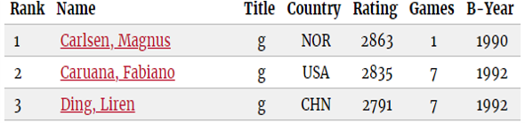

[figure not shown]

## What is Computer Chess?

- A.I. run from a software or hardware
- Allow players to play alone, train, or analyze
- Chess websites: Chess.com & Lichess.com
- Popular programs: Stockfish, Alpha Zero, Komodo, Deepblue
- Programs use: a chess engine and a graphical user interface

[figure not shown]

## How does Computer Chess function? (1)

- First, how do humans play?
- Abstract thought
- Spatial intelligence: memorizing and recognizing pattern positions
- Develop strategies
- Creativity (think out of the box)

## How does Computer Chess function? (2)

- A different paradigm than humans
- They don‘t think, they calculate
- Heuristic to build game trees
- Chess Algorithm
- First move: 20 possible moves, and 20 possible moves fom your opponent– 20x20= 400
- 2nd move: 400x20=8.000
- 3rd move: 8.000x20= 160.000
- And so on…

## How does Computer Chess function? (3)

- …. By the sixth move you have 1.2 billion possible variations
- We are still in the game opening
- Total existing possible game configurations: 10^120
- How many atoms are believed to be in the entire universe?
- 10^75
- You get the idea…
- How does the game tree calculation process works?
- Let‘s watch a Video! Link: https://www.youtube.com/watch?v=CFkhUajb8c8

## Application in R

- https://cran.r-project.org/web/packages/chess/index.html
- This package allows us to create and explore game trees

## Discussion

- „A.I. ruined Chess, now it‘s making the Game beautiful again“